# Palestinian Tech Labor Market

```python
!pip install fuzzywuzzy
!pip install python-Levenshtein
!pip install pandas
!pip install numpy
!pip install matplotlib
!pip install seaborn
!pip install openpyxl
```

```python
# Importing important packages

import numpy as np
import pandas as pd
import matplotlib.pyplot as plt
from fuzzywuzzy import fuzz
from fuzzywuzzy import process
import seaborn as sns
import matplotlib.colors as mcolors
```

## 1. Gather data

### **1.1.** Problem Statement

While searching for a dataset of Palestinian tech employees, I couldn't find any dataset that could help analyze the Palestinian labor market and tech experiences. So, I decided to collect some data using scraping methods on LinkedIn, and to address the privacy concerns I didn't collect any personal information. Moreover, to study the market, I collected another dataset of jobs with their skills, the importance of the skills, and other data to help analyze the market.

So, after merging these datasets, we can create visualizations to answer the following question:

- How do the most in-demand technical skills vary between different job roles in the Palestinian tech labor market?

### **1.2.** Datasets

Here are the available datasets:

- Palestinian LinkedIn Profiles
- Job Dataset

#### **1.2.1** **Dataset 1**: Palestinian LinkedIn Profiles

The dataset comprises LinkedIn profiles of Palestinian professionals, capturing a wide array of information including work experience, education, certifications, skills, and more. This comprehensive dataset was collected to analyze the tech labor market in Palestine, identify emerging trends, and enrich the available labor market data.

**Type**: *JSON Files*

**Method**: *The data was **scraped** from **LinkedIn** profiles using [APIFY Linkedin profile scraper tool](https://console.apify.com/actors/PEgClm7RgRD7YO94b/input)*

**Info**: The data was of **59 JSON files** since it was scraped using multiple bots. So, I merged them under 1 JSON file and removed any personal info to address any privacy concerns before we start digging here as shown below in the code snippet:

```
import pandas as pd
import os

folder_path = '/content/json'

files = [f for f in os.listdir(folder_path) if f.endswith('.json')]

columns_to_keep = [
    'id', 'jobTitle', 'occupation', 'headline', 'industryName',
    'geoCountryName', 'countryCode',
    'followersCount', 'connectionsCount', 'student',
    'companyName', 'companyPublicId', 'companyLinkedinUrl',
    'positions', 'educations', 'certifications', 'courses', 'honors', 'languages', 'skills', 'volunteerExperiences'
]

dataframes = []

for file in files:
    file_path = os.path.join(folder_path, file)
    df = pd.read_json(file_path)
    dataframes.append(df)

merged_df = pd.concat(dataframes, ignore_index=True)

df = merged_df[columns_to_keep]

def make_hashable(x):
    if isinstance(x, dict):
        return tuple((k, make_hashable(v)) for k, v in sorted(x.items()))
    elif isinstance(x, list):
        return tuple(make_hashable(i) for i in x)
    return x

for col in df.columns:
    df.loc[:, col] = df[col].apply(make_hashable)

df.to_json('out/palestinian_linkedin_profiles.json')

print('Merged and saved the DataFrame successfully.')
```

**Dataset variables**:

| Variable | Type | Description |
| --- | --- | --- |
| `id` | int64 | Unique identifier for each record |
| `jobTitle` | String | Job title of the individual |
| `occupation` | String | Current occupation of the individual |
| `headline` | String | Professional headline |
| `industryName` | String | Industry name |
| `geoCountryName` | String | Geographical country name |
| `countryCode` | String | Country code |
| `followersCount` | int64 | Number of followers |
| `connectionsCount` | int64 | Number of connections |
| `student` | bool | Whether the individual is a student |
| `companyName` | String | Name of the company |
| `companyPublicId` | String | Public identifier of the company |
| `companyLinkedinUrl` | Link | LinkedIn URL of the company |
| `positions` | Array of JSON | Positions held by the individual |
| `educations` | Array of JSON | Educational background |
| `certifications` | Array of JSON | Certifications acquired |
| `courses` | Array of JSON | Courses completed |
| `honors` | Array of JSON | Honors received |
| `languages` | Array of strings | Languages spoken |
| `skills` | Array of strings | Skills possessed |
| `volunteerExperiences` | Array of JSON | Volunteer experiences |

```python
# Load json dataset
df = pd.read_json('palestinian_linkedin_profiles.json')
```

```python
# Rows x Columns
df.shape
```

```
(967, 21)
```

```python
# get all unique values in df of column headline
df['headline'].unique().shape
```

```
(708,)
```

```python
df.info()
```

```
<class 'pandas.core.frame.DataFrame'>
Index: 967 entries, 0 to 966
Data columns (total 21 columns):
 #   Column                Non-Null Count  Dtype
---  ------                --------------  -----
 0   id                    967 non-null    int64
 1   jobTitle              920 non-null    object
 2   occupation            967 non-null    object
 3   headline              967 non-null    object
 4   industryName          965 non-null    object
 5   geoCountryName        964 non-null    object
 6   countryCode           967 non-null    object
 7   followersCount        967 non-null    int64
 8   connectionsCount      967 non-null    int64
 9   student               967 non-null    bool
 10  companyName           918 non-null    object
 11  companyPublicId       850 non-null    object
 12  companyLinkedinUrl    850 non-null    object
 13  positions             967 non-null    object
 14  educations            967 non-null    object
 15  certifications        967 non-null    object
 16  courses               967 non-null    object
 17  honors                967 non-null    object
 18  languages             967 non-null    object
 19  skills                967 non-null    object
 20  volunteerExperiences  967 non-null    object
dtypes: bool(1), int64(3), object(17)
memory usage: 159.6+ KB
```

#### **1.2.2** **Dataset 2**: Job Dataset

The dataset contains a list of skills associated with whether the skill is important or not which will help us identify the important expertise in the Palestinian Labor Tech Market.

**Type**: *XLSX File*

**Method**: *The data was **Downloaded** and used from **Kaggle** at this link: [List of all the skills](https://www.kaggle.com/datasets/arbazkhan971/allskillandnonskill)*

**Dataset variables:**

| Column Name | Data Type | Description |
| --- | --- | --- |
| O*NET-SOC Code | String | O*NET-SOC code assigned to the job position. |
| Title | String | Job title associated with the O*NET-SOC code. |
| Example | String | Example skill relevant to the job position. |
| Commodity Code | int64 | Code related to commodities associated with the job. |
| Commodity Title | String | Title of the commodity associated with the job. |
| Hot Technology | String | Indicates if the technology is considered 'hot' or in-demand (Yes/No). |

```python
# Read the dataset
df2 = pd.read_excel('technology_skills.xlsx')
```

```python
# Rows x Columns
df2.shape
```

```
(27858, 6)
```

```python
df2.info()
```

```
<class 'pandas.core.frame.DataFrame'>
RangeIndex: 27858 entries, 0 to 27857
Data columns (total 6 columns):
 #   Column           Non-Null Count  Dtype
---  ------           --------------  -----
 0   O*NET-SOC Code   27858 non-null  object
 1   Title            27858 non-null  object
 2   Example          27858 non-null  object
 3   Commodity Code   27858 non-null  int64
 4   Commodity Title  27858 non-null  object
 5   Hot Technology   27858 non-null  object
dtypes: int64(1), object(5)
memory usage: 1.3+ MB
```

## 2. Assess data

### Quality Issue 1: Non-worker Profiles

```python
# Showing the profiles that are not related to employees
non_workers = df[df['jobTitle'].isna()]
non_workers.head(2)
```

|  | id | jobTitle | occupation | headline | industryName | geoCountryName | countryCode | followersCount | connectionsCount | student | ... | companyPublicId | companyLinkedinUrl | positions | educations | certifications | courses | honors | languages | skills | volunteerExperiences |
| --- | --- | --- | --- | --- | --- | --- | --- | --- | --- | --- | --- | --- | --- | --- | --- | --- | --- | --- | --- | --- | --- |
| 10 | 797799692 | None | QA Automation Engineer @ Logitude \| Computer S... | QA Automation Engineer @ Logitude \| Computer ... | Software Development | Palestinian Authority | ps | 312 | 314 | False | ... | None | None | [] | [[[degreeName, Bachelor's degree], [fieldOfStu... | [[[authority, LinkedIn], [name, Java: Data Str... | [] | [] | [] | [Java, Object-Oriented Programming (OOP), Netw... | [] |
| 11 | 1009046231 | None | Software Engineer | Software Engineer | Software Development | Palestinian Authority | ps | 171 | 142 | False | ... | None | None | [] | [[[degreeName, Bachelor's degree], [fieldOfStu... | [[[authority, IEEE An-Najah Student Branch], [... | [] | [] | [] | [Node.js, JavaScript, ASP.NET, .NET Framework] | [[[companyName, IEEE An-Najah Student Branch],... |

2 rows × 21 columns

```python
# The number of non-workers
print(f'Number of non-workers: {non_workers.shape[0]}')
```

```
Number of non-workers: 47
```

The issue here that we need to exclude and remove the non-workers because our goal is to analyze employees in the tech market. So it could happen while scraping profiles that we scraped non-workers profiles.

### Quality Issue 2: Removing Duplicates

```python
df_duplicates = df[df['id'].duplicated(keep=False)]
```

```python
# The duplicated profiles
df_duplicates.sort_values(by='id').head()
```

|  | id | jobTitle | occupation | headline | industryName | geoCountryName | countryCode | followersCount | connectionsCount | student | ... | companyPublicId | companyLinkedinUrl | positions | educations | certifications | courses | honors | languages | skills | volunteerExperiences |
| --- | --- | --- | --- | --- | --- | --- | --- | --- | --- | --- | --- | --- | --- | --- | --- | --- | --- | --- | --- | --- | --- |
| 427 | 100612178 | IT Consultant | IT Consultant at AXSOS AG | IT Consultant at AXSOS AG | IT Services and IT Consulting | Palestinian Authority | ps | 498 | 499 | False | ... | axsos-ag | https://www.linkedin.com/company/axsos-ag | [[[company, [['active', True], ['dashCompanyUr... | [[[degreeName, network administrater and secur... | [[[authority, CompTIA], [name, A+ IT Technicia... | [] | [] | [] | [System Administration, Network Administration... | [] |
| 379 | 100612178 | IT Consultant | IT Consultant at AXSOS AG | IT Consultant at AXSOS AG | IT Services and IT Consulting | Palestinian Authority | ps | 498 | 499 | False | ... | axsos-ag | https://www.linkedin.com/company/axsos-ag | [[[company, [['active', True], ['dashCompanyUr... | [[[degreeName, network administrater and secur... | [[[authority, CompTIA], [name, A+ IT Technicia... | [] | [] | [] | [System Administration, Network Administration... | [] |
| 422 | 156205436 | Senior Infrastructure & DevOps Engineer | Senior Infrastructure & DevOps Engineer at AUI... | Senior Infrastructure & DevOps Engineer at AUI... | Software Development | Palestinian Authority | ps | 3401 | 500 | False | ... | augmentedintelligence-aui | https://www.linkedin.com/company/augmentedinte... | [[[company, [['active', True], ['dashCompanyUr... | [[[degreeName, Bachelor's degree], [fieldOfStu... | [[[authority, AXELOS Global Best Practice], [n... | [] | [[[description, A scholarship to study Bachelo... | [[[name, Arabic], [proficiency, NATIVE_OR_BILI... | [Microsoft Office, Linux, Amazon Web Services ... | [] |
| 374 | 156205436 | Senior Infrastructure & DevOps Engineer | Senior Infrastructure & DevOps Engineer at AUI... | Senior Infrastructure & DevOps Engineer at AUI... | Software Development | Palestinian Authority | ps | 3401 | 500 | False | ... | augmentedintelligence-aui | https://www.linkedin.com/company/augmentedinte... | [[[company, [['active', True], ['dashCompanyUr... | [[[degreeName, Bachelor's degree], [fieldOfStu... | [[[authority, AXELOS Global Best Practice], [n... | [] | [[[description, A scholarship to study Bachelo... | [[[name, Arabic], [proficiency, NATIVE_OR_BILI... | [Microsoft Office, Linux, Amazon Web Services ... | [] |
| 373 | 167441662 | Quality Assurance Engineer at PWA | Quality Assurance Engineer at PWA | Quality Assurance Engineer at PWA | Civil Engineering | Palestinian Authority | ps | 390 | 392 | False | ... | palestinian-water-authority | https://www.linkedin.com/company/palestinian-w... | [[[company, [['active', True], ['dashCompanyUr... | [[[degreeName, Bachelor's degree], [fieldOfStu... | [] | [] | [] | [] | [Civil Engineering, Water, Construction Manage... | [] |

5 rows × 21 columns

```python
# The number of duplicated profiles print with message
print(f'Number of duplicated profiles: {df_duplicates.shape[0]}')
```

```
Number of duplicated profiles: 86
```

```python
df2_duplicates = df2[df2['Example'].duplicated(keep=False)]
```

```python
df2_duplicates.sort_values(by='Example').head()
```

|  | O*NET-SOC Code | Title | Example | Commodity Code | Commodity Title | Hot Technology |
| --- | --- | --- | --- | --- | --- | --- |
| 26506 | 51-4011.00 | Computer-Controlled Machine Tool Operators, Me... | 1CadCam Unigraphics | 43232612 | Computer aided manufacturing CAM software | N |
| 12633 | 17-3012.01 | Electronic Drafters | 1CadCam Unigraphics | 43232612 | Computer aided manufacturing CAM software | N |
| 12689 | 17-3013.00 | Mechanical Drafters | 1CadCam Unigraphics | 43232612 | Computer aided manufacturing CAM software | N |
| 11768 | 17-2141.00 | Mechanical Engineers | 1CadCam Unigraphics | 43232612 | Computer aided manufacturing CAM software | N |
| 18309 | 27-1021.00 | Commercial and Industrial Designers | 1CadCam Unigraphics | 43232612 | Computer aided manufacturing CAM software | N |

```python
# The number of duplicated profiles print with message
print(f'Number of duplicated skills: {df2_duplicates.shape[0]}')
```

```
Number of duplicated skills: 21298
```

While scraping the LinkedIn Profiles using multiple bots which led to duplicates in the dataset, so we need to make sure to eliminate those.

Also, we need to make sure we don't have duplicated skills.

### Tidiness Issue 1: Incorrect Data Types

```python
# Hot Technology has values Y/N but should be in bool values
df2.head()
```

|  | O*NET-SOC Code | Title | Example | Commodity Code | Commodity Title | Hot Technology |
| --- | --- | --- | --- | --- | --- | --- |
| 0 | 11-1011.00 | Chief Executives | Adobe Systems Adobe Acrobat | 43232202 | Document management software | Y |
| 1 | 11-1011.00 | Chief Executives | AdSense Tracker | 43232306 | Data base user interface and query software | N |
| 2 | 11-1011.00 | Chief Executives | Atlassian JIRA | 43232201 | Content workflow software | Y |
| 3 | 11-1011.00 | Chief Executives | Blackbaud The Raiser's Edge | 43232303 | Customer relationship management CRM software | Y |
| 4 | 11-1011.00 | Chief Executives | ComputerEase Construction Accounting | 43231601 | Accounting software | N |

```python
# The data type of Job Posting Date
print(f'Data type of Job Posting Date: {df2["Hot Technology"].dtype}')
```

```
Data type of Job Posting Date: object
```

**Issue and justification**

- The 'Hot Technology' is an object in df2 but needs to be as a bool type so we can easily search, and compare between skills.

### Tidiness Issue 2: Atomicity - Some columns are arrays

```python
# Show the issue of columns contain arrays of values in df
df['skills'].head()
```

```
0    [User Requirements, Emerging Technologies, Mul...
1    [Java, Object-Oriented Programming (OOP), Pyth...
2              [React, Angular, TypeScript, AngularJS]
3    [Automated Software Testing, NestJS, Continuou...
4    [Windows Server, Active Directory, F-Secure, S...
Name: skills, dtype: object
```

```python
# Inspecting the dataframe programmatically

# Inspecting DataFrame df
print("Inspecting DataFrame df:")
print("------------------------")

# Check the column type
skills_type_df = df['skills'].apply(type).unique()
print("Skills column type in df:", skills_type_df)

# Inspect unique values
unique_skills_df = df['skills'].explode().unique()
print("Unique skills in df:")
# print first 5 skills
print(unique_skills_df[:3])

# Check for missing values
missing_values_df = df['skills'].isnull().sum()
print("Missing values in skills column of df:", missing_values_df)
```

```
Inspecting DataFrame df:
------------------------
Skills column type in df: [<class 'list'>]
Unique skills in df:
['User Requirements' 'Emerging Technologies' 'Multithreading']
Missing values in skills column of df: 0
```

**Issue and justification**

The issue involves inconsistent data formats in the skills column between two DataFrames (df and df2). df uses lists (e.g., ['User Requirements', 'Emerging Technologies']), while df2 employs strings (e.g., 'Supplier diversity programs Diversity'). Standardizing the representation of skills across both datasets is essential for ensuring data consistency and facilitating accurate analysis and visualization.

## 3. Clean data

```python
# Make copies of the datasets to ensure the raw dataframes
df_clean = df.copy()
df2_clean = df2.copy()
```

### **Quality Issue 1: Non-worker Profiles**

```python
# Remove non-workers from df where the jobTitle are null/empty
df_clean = df_clean[~df_clean['jobTitle'].isna()]
```

```python
# Validate the cleaning was successful
# print the length of df and df_clean
print(f'Length of df: {len(df)} before cleaning')
print(f'Length of df_clean: {len(df_clean)} after cleaning')
non_workers = df_clean[df_clean['jobTitle'].isna()]
non_workers.head()
```

```
Length of df: 967 before cleaning
Length of df_clean: 920 after cleaning
```

|  | id | jobTitle | occupation | headline | industryName | geoCountryName | countryCode | followersCount | connectionsCount | student | ... | companyPublicId | companyLinkedinUrl | positions | educations | certifications | courses | honors | languages | skills | volunteerExperiences |
| --- | --- | --- | --- | --- | --- | --- | --- | --- | --- | --- | --- | --- | --- | --- | --- | --- | --- | --- | --- | --- | --- |

0 rows × 21 columns

**Justification**

- Remove Non-workers: The code filters out rows from df_clean where jobTitle is null or empty, removing non-workers.
- Validate Cleaning: Prints the lengths of the original DataFrame (df) and the cleaned DataFrame (df_clean) to compare and ensure rows were removed.
- Confirm Success: Checks for any remaining non-workers in df_clean to confirm all such rows have been successfully excluded.

### **Quality Issue 2: Removing Duplicates**

```python
# Remove duplicates, keeping only the first occurrence
df_clean = df_clean.drop_duplicates(subset='id', keep='first')
```

```python
# Validate the cleaning was successful
print(f'Length of df: {len(df)} before removing duplicates')
print(f'Length of df_clean: {len(df_clean)} after removing duplicates')
df_duplicates = df_clean[df_clean['id'].duplicated(keep=False)]
df_duplicates.head()
```

```
Length of df: 967 before removing duplicates
Length of df_clean: 873 after removing duplicates
```

|  | id | jobTitle | occupation | headline | industryName | geoCountryName | countryCode | followersCount | connectionsCount | student | ... | companyPublicId | companyLinkedinUrl | positions | educations | certifications | courses | honors | languages | skills | volunteerExperiences |
| --- | --- | --- | --- | --- | --- | --- | --- | --- | --- | --- | --- | --- | --- | --- | --- | --- | --- | --- | --- | --- | --- |

0 rows × 21 columns

```python
# Remove duplicates from df2 based on Example column
df2_clean = df2_clean.drop_duplicates(subset='Example', keep='first')
```

```python
# Validate the cleaning was successful
print(f'Length of df2: {len(df2)} before removing duplicates')
print(f'Length of df2_clean: {len(df2_clean)} after removing duplicates')
df_duplicates = df2_clean[df2_clean['Example'].duplicated(keep=False)]
df_duplicates.head()
```

```
Length of df2: 27858 before removing duplicates
Length of df2_clean: 8824 after removing duplicates
```

|  | O*NET-SOC Code | Title | Example | Commodity Code | Commodity Title | Hot Technology |
| --- | --- | --- | --- | --- | --- | --- |

**Justification**

- Remove Duplicates: Removes duplicate rows from df_clean based on the id column, keeping only the first occurrence of each unique id.
- Ensure Data Integrity: Prevents redundant data entries and ensures each id is unique within the DataFrame.
- Validate Cleaning: Compares the lengths of the original DataFrame (df) and the cleaned DataFrame (df_clean) to confirm the successful removal of duplicates.
- Double-check for Duplicates: Checks for any remaining duplicates in df_clean to ensure the cleaning process was thorough and effective.

### **Tidiness Issue 1: Incorrect Data Types**

```python
# Convert 'date' column to datetime type
df2_clean['Hot Technology'] = df2_clean['Hot Technology'].map({'Y': True, 'N': False})
```

```python
# Standardize df_clean to have skills as lists
df_clean['skills'] = df_clean['skills'].apply(lambda x: x if isinstance(x, list) else [x])
```

```python
# Validate the cleaning was successful
print(f'Data type of Hot Technology: {df2_clean["Hot Technology"].dtype}')
print(f'Skills column type in df: {df_clean["skills"].apply(type).unique()}')
```

```
Data type of Hot Technology: bool
Skills column type in df: [<class 'list'>]
```

**Justification**

These operations ensure data consistency, improve analysis accuracy, and prepare the DataFrames for subsequent data manipulation and exploration tasks.

### **Tidiness Issue 2: Atomicity - Some columns are arrays**

```python
# Using explode() on df & df2 to unnest lists into rows
df_clean = df_clean.explode('skills')
```

```python
# Validate the cleaning was successful for df
df_clean.head()
```

|  | id | jobTitle | occupation | headline | industryName | geoCountryName | countryCode | followersCount | connectionsCount | student | ... | companyPublicId | companyLinkedinUrl | positions | educations | certifications | courses | honors | languages | skills | volunteerExperiences |
| --- | --- | --- | --- | --- | --- | --- | --- | --- | --- | --- | --- | --- | --- | --- | --- | --- | --- | --- | --- | --- | --- |
| 0 | 493425084 | iOS Developer | iOS Developer at Upwork | iOS Developer at Upwork | Information Technology & Services | Palestinian Authority | ps | 1132 | 500 | False | ... | upwork | https://www.linkedin.com/company/upwork | [[[company, [['active', True], ['dashCompanyUr... | [[[degreeName, Bachelor's degree], [fieldOfStu... | [] | [] | [] | [[[name, Arabic]], [[name, English]]] | User Requirements | [[[companyName, IEEE], [role, treasurer]]] |
| 0 | 493425084 | iOS Developer | iOS Developer at Upwork | iOS Developer at Upwork | Information Technology & Services | Palestinian Authority | ps | 1132 | 500 | False | ... | upwork | https://www.linkedin.com/company/upwork | [[[company, [['active', True], ['dashCompanyUr... | [[[degreeName, Bachelor's degree], [fieldOfStu... | [] | [] | [] | [[[name, Arabic]], [[name, English]]] | Emerging Technologies | [[[companyName, IEEE], [role, treasurer]]] |
| 0 | 493425084 | iOS Developer | iOS Developer at Upwork | iOS Developer at Upwork | Information Technology & Services | Palestinian Authority | ps | 1132 | 500 | False | ... | upwork | https://www.linkedin.com/company/upwork | [[[company, [['active', True], ['dashCompanyUr... | [[[degreeName, Bachelor's degree], [fieldOfStu... | [] | [] | [] | [[[name, Arabic]], [[name, English]]] | Multithreading | [[[companyName, IEEE], [role, treasurer]]] |
| 0 | 493425084 | iOS Developer | iOS Developer at Upwork | iOS Developer at Upwork | Information Technology & Services | Palestinian Authority | ps | 1132 | 500 | False | ... | upwork | https://www.linkedin.com/company/upwork | [[[company, [['active', True], ['dashCompanyUr... | [[[degreeName, Bachelor's degree], [fieldOfStu... | [] | [] | [] | [[[name, Arabic]], [[name, English]]] | Debugging | [[[companyName, IEEE], [role, treasurer]]] |
| 1 | 334055532 | Software Engineer | Software Engineer at NVIDIA | Software Engineer at NVIDIA | Computer Software | Palestinian Authority | ps | 849 | 500 | False | ... | nvidia | https://www.linkedin.com/company/nvidia | [[[company, [['active', True], ['dashCompanyUr... | [[[degreeName, Bachelor's degree], [fieldOfStu... | [] | [[[name, Computer and Laptop maintenance ]]] | [] | [[[name, English], [proficiency, PROFESSIONAL_... | Java | [] |

5 rows × 21 columns

**Justification**

**Standardization**: The lambda functions applied to df['skills'] ensure that each entry in the skills column is converted to a list, regardless of its initial format.

**Exploding Lists**: df.explode('skills') is used to unnest the lists in df into separate rows, ensuring each skill has its own row for consistent data handling.

### **Remove unnecessary variables and combine datasets**

#### Remove unnecessary variables

```python
# Remove unnecessary variables and combine datasets

# List of columns to drop
columns_to_drop = [
    'occupation', 'headline', 'geoCountryName', 'countryCode',
    'followersCount', 'connectionsCount', 'companyPublicId',
    'companyLinkedinUrl', 'educations', 'certifications', 'student',
    'courses', 'honors', 'languages', 'volunteerExperiences', 'positions', 'companyName', 'industryName',
]

# Drop the specified columns from df
df_clean = df_clean.drop(columns=columns_to_drop)

# Print the cleaned DataFrame
print("DataFrame after dropping specified columns:")
df_clean.info()
```

```
DataFrame after dropping specified columns:
<class 'pandas.core.frame.DataFrame'>
Index: 3266 entries, 0 to 966
Data columns (total 3 columns):
 #   Column    Non-Null Count  Dtype
---  ------    --------------  -----
 0   id        3266 non-null   int64
 1   jobTitle  3266 non-null   object
 2   skills    3208 non-null   object
dtypes: int64(1), object(2)
memory usage: 102.1+ KB
```

```python
# List of columns to drop
columns_to_drop = ['O*NET-SOC Code',	'Title',	'Commodity Code',	'Commodity Title']

# Drop the specified columns from df
df2_clean = df2_clean.drop(columns=columns_to_drop)

# Print the cleaned DataFrame
print("DataFrame after dropping specified columns:")
df2_clean.info()
```

```
DataFrame after dropping specified columns:
<class 'pandas.core.frame.DataFrame'>
Index: 8824 entries, 0 to 27854
Data columns (total 2 columns):
 #   Column          Non-Null Count  Dtype
---  ------          --------------  -----
 0   Example         8824 non-null   object
 1   Hot Technology  8824 non-null   bool
dtypes: bool(1), object(1)
memory usage: 146.5+ KB
```

**Extra important steps**

- Of adding new, renaming, correcting columns.
- Standardizing the skills

```python
# We need a unique id for df2_clean
df2_clean['id'] = range(len(df2_clean))

# Rename columns in df2 Example and Hot Technology to skills and is_hot_technology
df2_clean = df2_clean.rename(columns={'Example': 'skills', 'Hot Technology': 'is_hot_technology'})

# Rename columns in df jobTitle to job_title
df_clean = df_clean.rename(columns={'jobTitle': 'job_title'})

# Make skills in both dfs lower case
df_clean['skills'] = df_clean['skills'].str.lower()
df2_clean['skills'] = df2_clean['skills'].str.lower()
```

```python
df_clean.reset_index(drop=True, inplace=True)
df2_clean.reset_index(drop=True, inplace=True)
```

**Justification**

- Ensure Unique Index: Resets the index of df_clean and df2_clean to ensure that each DataFrame has a unique index, preventing potential errors during data manipulation and analysis.
- Facilitate Data Operations: A unique index is essential for various DataFrame operations, such as merging, joining, and dropping columns, ensuring smooth and error-free execution.
- Improve Data Integrity: Reseting the index helps maintain the integrity of the DataFrames by removing any index duplicates or inconsistencies that might have arisen during previous data transformations.

#### Combine datasets

Before we combine the datasets, let's look at them so we have a better sense of the data.

```python
df_clean.head()
```

|  | id | job_title | skills |
| --- | --- | --- | --- |
| 0 | 493425084 | iOS Developer | user requirements |
| 1 | 493425084 | iOS Developer | emerging technologies |
| 2 | 493425084 | iOS Developer | multithreading |
| 3 | 493425084 | iOS Developer | debugging |
| 4 | 334055532 | Software Engineer | java |

```python
df2_clean.head()
```

|  | skills | is_hot_technology | id |
| --- | --- | --- | --- |
| 0 | adobe systems adobe acrobat | True | 0 |
| 1 | adsense tracker | False | 1 |
| 2 | atlassian jira | True | 2 |
| 3 | blackbaud the raiser's edge | True | 3 |
| 4 | computerease construction accounting | False | 4 |

##### Combine the 2 datasets

```python
df_clean.shape
```

```
(3266, 3)
```

```python
df2_clean.shape
```

```
(8824, 3)
```

```python
# Merge df_clean with df2_clean based on skils using left join

progress_counter = 0
total = len(df_clean)

# Function to find the best match and similarity score
def get_best_match(skill, choices):
    global progress_counter
    global total
    progress_counter += 1
    print(f'Progress: {progress_counter}/{total}') if progress_counter % 100 == 0 else None

    # Convert skill to string
    skill = str(skill)

    # Find choices that contain the skill
    containing_choices = [choice for choice in choices if skill in choice]

    if containing_choices:
      try:
          # If there are multiple choices, find the best match among them
          match = process.extractOne(skill, containing_choices, scorer=fuzz.token_sort_ratio)
          if match:
              return match[0], match[1]
          else:
              return None, 0
      except Exception as e:
          print(f"Error processing skill '{skill}': {e}")
          return None, 0
    else:
      try:
          # If there are multiple choices, find the best match among them
          match = process.extractOne(skill, choices, scorer=fuzz.token_sort_ratio)
          if match:
              return match[0], match[1]
          else:
              return None, 0
      except Exception as e:
          print(f"Error processing skill '{skill}': {e}")
          return None, 0

# Find the best matches for each skill in df_clean from df2_clean
matches = df_clean['skills'].apply(lambda x: get_best_match(x, df2_clean['skills']))

# Extract the best matches and scores into separate columns
df_clean['best_match'] = [match[0] for match in matches]
df_clean['similarity'] = [match[1] for match in matches]

# Merge with df2_clean based on the best matches (left join)
merged_df = pd.merge(df_clean, df2_clean, left_on='best_match', right_on='skills', how='left', suffixes=('_df1', '_df2'))
```

```
Progress: 100/3266
Progress: 200/3266
Progress: 300/3266
Progress: 400/3266
Progress: 500/3266
Progress: 600/3266
Progress: 700/3266
Progress: 800/3266
Progress: 900/3266
Progress: 1000/3266
Progress: 1100/3266
Progress: 1200/3266
Progress: 1300/3266
Progress: 1400/3266
Progress: 1500/3266
Progress: 1600/3266
Progress: 1700/3266
Progress: 1800/3266
Progress: 1900/3266
Progress: 2000/3266
Progress: 2100/3266
Progress: 2200/3266
Progress: 2300/3266
Progress: 2400/3266
Progress: 2500/3266
Progress: 2600/3266
Progress: 2700/3266
Progress: 2800/3266
Progress: 2900/3266
Progress: 3000/3266
Progress: 3100/3266
Progress: 3200/3266
```

```python
# Print the shape of the combined DataFrame with message
print(f'Shape of combined DataFrame: {merged_df.shape}')
merged_df.head(5)
```

```
Shape of combined DataFrame: (3316, 8)
```

|  | id_df1 | job_title | skills_df1 | best_match | similarity | skills_df2 | is_hot_technology | id_df2 |
| --- | --- | --- | --- | --- | --- | --- | --- | --- |
| 0 | 493425084 | iOS Developer | user requirements | requirements analysis software | 64 | requirements analysis software | False | 2913 |
| 1 | 493425084 | iOS Developer | emerging technologies | emerging technologies office center | 75 | emerging technologies office center | True | 798 |
| 2 | 493425084 | iOS Developer | multithreading | trading blox | 62 | trading blox | False | 7419 |
| 3 | 493425084 | iOS Developer | debugging | debugging software | 67 | debugging software | False | 2601 |
| 4 | 334055532 | Software Engineer | java | javascript | 57 | javascript | True | 197 |

```python
# print merged_df where the skill_df2 is None
print(f'Number of rows where the skill_df2 is None: {merged_df[merged_df["skills_df2"].isna()].shape[0]}')

# print merged_df where the skill_df is None
print(f'Number of rows where the skill_df is None: {merged_df[merged_df["skills_df1"].isna()].shape[0]}')

# The incorrect NaN matches should be cleaned in skills_df2
merged_df[merged_df["skills_df1"].isna()].head()
```

```
Number of rows where the skill_df2 is None: 0
Number of rows where the skill_df is None: 58
```

|  | id_df1 | job_title | skills_df1 | best_match | similarity | skills_df2 | is_hot_technology | id_df2 |
| --- | --- | --- | --- | --- | --- | --- | --- | --- |
| 122 | 890173126 | Frontend Developer | NaN | sap maintenance | 33 | sap maintenance | True | 8233 |
| 175 | 1065902643 | Computer Systems Engineer | NaN | sap maintenance | 33 | sap maintenance | True | 8233 |
| 252 | 1021175980 | QA/QC | NaN | sap maintenance | 33 | sap maintenance | True | 8233 |
| 306 | 733374276 | Software Engineer | NaN | sap maintenance | 33 | sap maintenance | True | 8233 |
| 348 | 853599189 | Quality Assurance Engineer | NaN | sap maintenance | 33 | sap maintenance | True | 8233 |

##### Let's Do some cleaning after combining the dataframes

```python
# The duplicated rows
print(f'Number of duplicated rows before removal: {merged_df[merged_df.duplicated()].shape[0]}')
```

```
Number of duplicated rows before removal: 1
```

```python
# Drop duplicates
merged_df = merged_df.drop_duplicates(keep='first')
```

```python
# The duplicated rows after removal
print(f'Number of duplicated rows after removal: {merged_df[merged_df.duplicated()].shape[0]}')
```

```
Number of duplicated rows after removal: 0
```

```python
# Remove rows when skills_df1 is NaN
merged_df = merged_df[merged_df['skills_df1'].notna()]
```

```python
# Verify the incorrect NaN matches should be cleaned in skills_df2
merged_df[merged_df["skills_df1"].isna()].head()
```

|  | id_df1 | job_title | skills_df1 | best_match | similarity | skills_df2 | is_hot_technology | id_df2 |
| --- | --- | --- | --- | --- | --- | --- | --- | --- |

```python
# Drop unnecessary columsn from merged_df
merged_df = merged_df.drop(['best_match', 'similarity', 'skills_df2', 'id_df2'], axis=1)
```

## 4. Update your data store

```python
# Saving data
df_clean.to_json('palestinian_linkedin_profiles_cleaned.json')
df2_clean.to_csv('technology_skills_cleaned.csv', index=False)
merged_df.to_csv('palestinian_linkedin_profiles_merged.csv', index=False)
```

## 5. Answer the research question

### **5.1:** Define and answer the research question

**Research question**: How do the most in-demand technical skills vary between different job roles in the Palestinian tech labor market?

### **5.2:** Visualization 1: Top 10 Hot Skills Across Different Job Roles

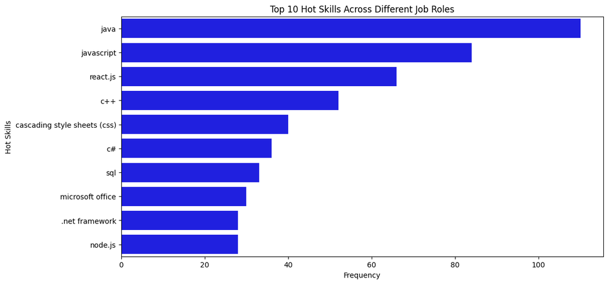

```python
# Filter for hot technologies
hot_tech_df = merged_df[merged_df['is_hot_technology']]

# Top 10 Hot Skills Across Different Job Roles
top_hot_skills = hot_tech_df['skills_df1'].value_counts().nlargest(10)

plt.figure(figsize=(12, 6))
sns.barplot(x=top_hot_skills.values, y=top_hot_skills.index, color='b')
plt.title('Top 10 Hot Skills Across Different Job Roles')
plt.xlabel('Frequency')
plt.ylabel('Hot Skills')
plt.show()
```

**Answer to research question**:

This visualization can display the most common skills required for various job roles (e.g., software developer, data analyst, IT support). So, as we can see from the visualization, the most frequent hot skills across the Palestinian Tech Labor Market are by order:

1. Java
2. JavaScript
3. ReactJS
4. C++
5. CSS
6. C#
7. SQL
8. Microsoft Office
9. .Net Framework
10. Node.js

### **5.3:** Visualization 2: Heatmap of Hot Skill Frequency by Job Role

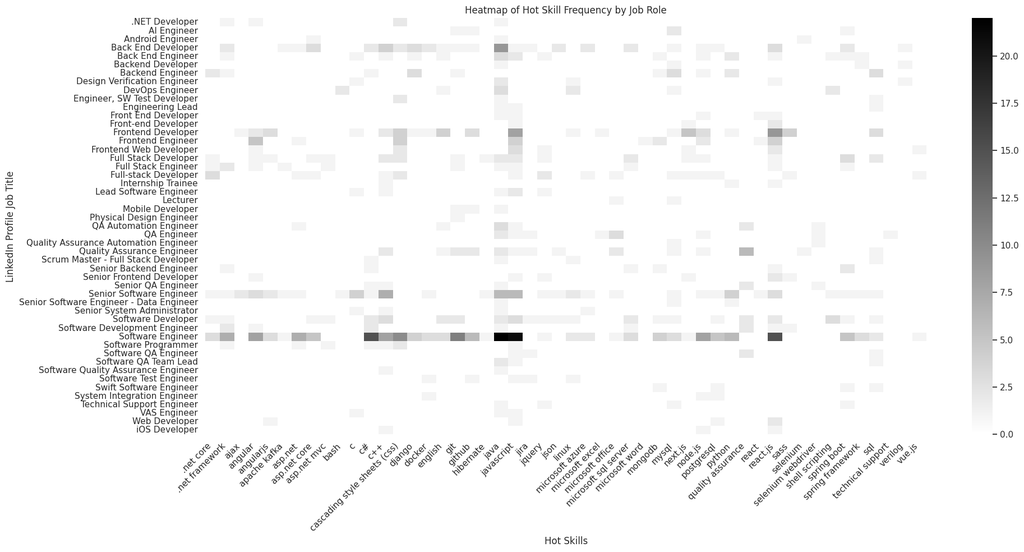

```python
# Filter for hot technologies
hot_tech_df = merged_df[merged_df['is_hot_technology']]

# Top 10 Job Titles
top_job_titles = hot_tech_df['job_title'].value_counts().nlargest(50).index

# Top 10 Hot Skills
top_hot_skills = hot_tech_df['skills_df1'].value_counts().nlargest(50).index

# Filter the DataFrame for top job titles and skills
filtered_df = hot_tech_df[hot_tech_df['job_title'].isin(top_job_titles) & hot_tech_df['skills_df1'].isin(top_hot_skills)]

# Heatmap of Hot Skill Frequency by Job Role
heatmap_data = filtered_df.pivot_table(index='job_title', columns='skills_df1', aggfunc='size', fill_value=0)

cmap = mcolors.LinearSegmentedColormap.from_list("white_black", ["white", "black"])

plt.figure(figsize=(20, 10))
sns.set(style="white")
fig, ax = plt.subplots(figsize=(20, 10))
fig.patch.set_facecolor('white')
ax.set_facecolor('white')
sns.heatmap(heatmap_data, annot=False, cmap=cmap, cbar=True, ax=ax)
plt.title('Heatmap of Hot Skill Frequency by Job Role')
plt.xlabel('Hot Skills')
plt.ylabel('LinkedIn Profile Job Title')
plt.xticks(rotation=45, ha='right')
plt.yticks(rotation=0)
plt.tight_layout()
plt.show()
```

**Answer to research question**:

### **5.2:** Reflection

By analyzing the data through these visualizations, we can gain insights into which technical skills are most sought after in the Palestinian tech labor market and how these skills are distributed across various job roles. Here are the top 3 skills:

1. Java
2. JavaScript
3. ReactJS

This information can be valuable for job seekers to tailor their skillsets to market demands and for educators or training providers to design relevant curricula and training programs.

Also, in the future we can improve the Palestinian LinkedIn Profiles Dataset by:

1. Standardizing the job titles (e.g. Front end engineer and Frontend Engineer are the same).
2. Find more profiles to enrich the dataset.

Further Questions in the future:

1. How does taking courses affect getting a job?
2. How does the University affect their students to get a job after graduation?